# R4DS Solutions

3. Compare and contrast geom_jitter() with geom_count().

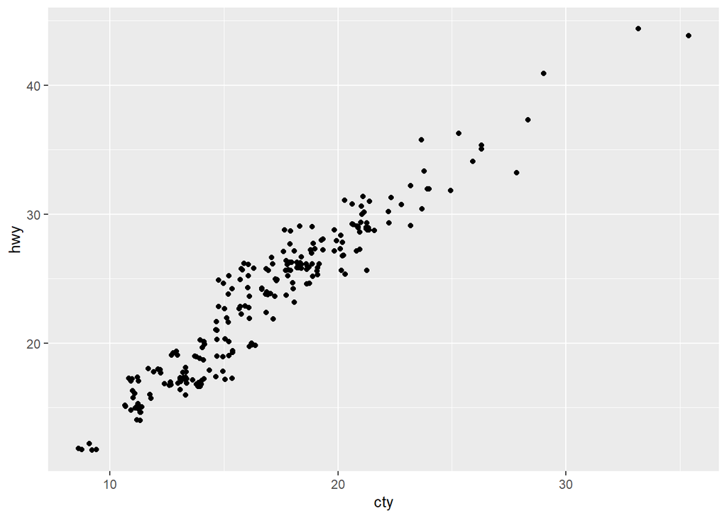

```r
?geom_jitter
?geom_count

ggplot(data = mpg, mapping = aes(x = cty, y = hwy)) +
  geom_jitter()
```

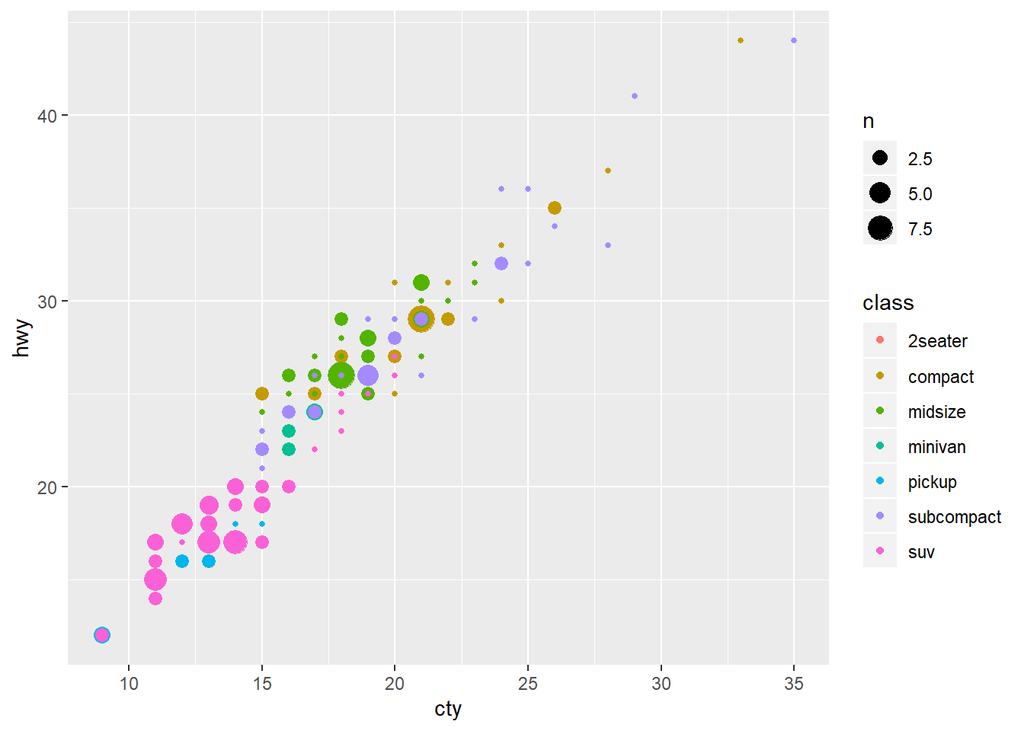

```r
ggplot(data = mpg, mapping = aes(x = cty, y = hwy)) +
  geom_count(aes(color = class))
```

geom_count is a variation of the geom_point, that counts the number of observations at each location and sizes the points relative to the counts. Useful when we have discrete data and overplotting. geom_jitter also handles overplotting caused by discrete data. But it handles this overplotting by adding small amount of random variation to the location of each point.

4. What’s the default position adjustment for geom_boxplot()? Create a visualisation of the mpg dataset that demonstrates it.

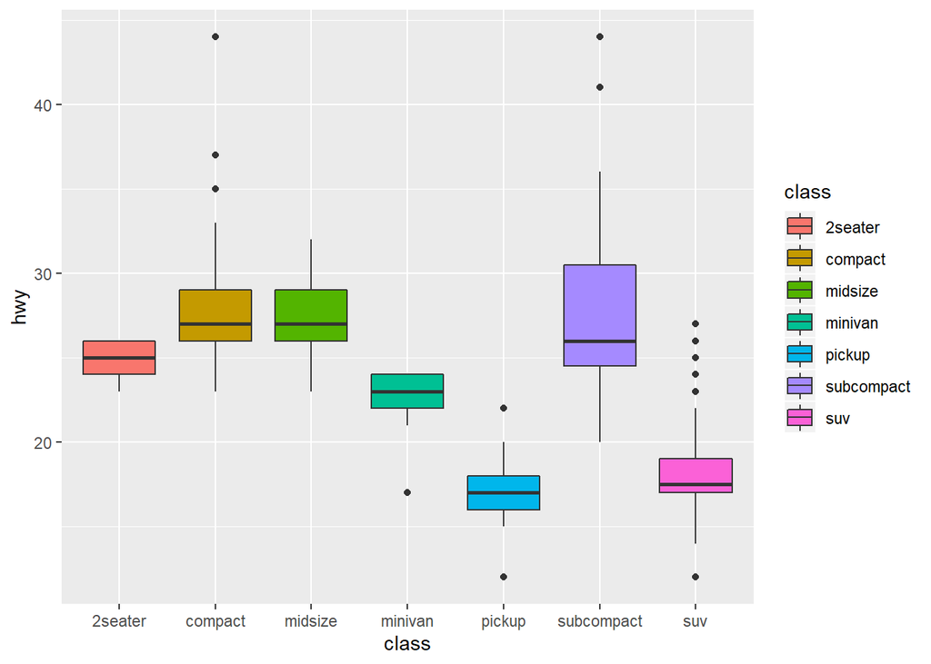

```r
?geom_boxplot

ggplot(data = mpg, mapping = aes(x = class, y = hwy)) +
  geom_boxplot(aes(fill = class))
```

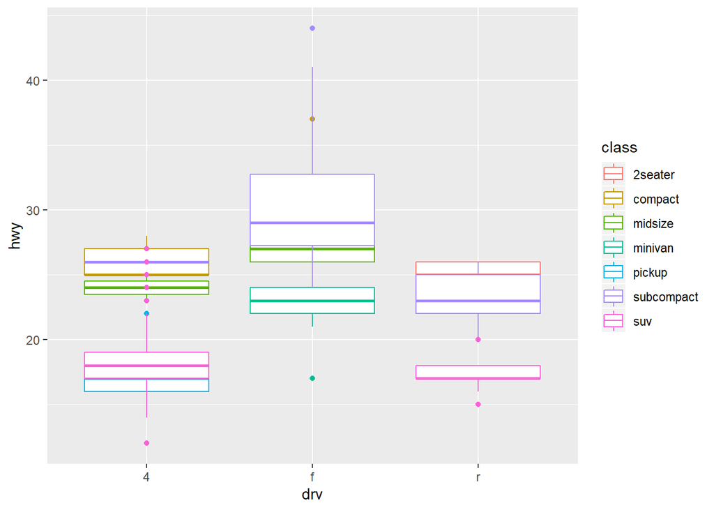

```r
ggplot(data = mpg, aes(x = drv, y = hwy, colour = class)) +
  geom_boxplot(position = "identity")
```

dodge2 is the default position adjustment for geom_boxplot. Available position adjustments: position_identity - default of most geoms position_jitter - default of geom_jitter position_dodge - default of geom_boxplot position_stack - default of geom_bar==geom_histogram and geom_area position_fill - useful for geom_bar==geom_histogram and geom_area

### 3.9 Coordinate systems

1.Turn a stacked bar chart into a pie chart using coord_polar()

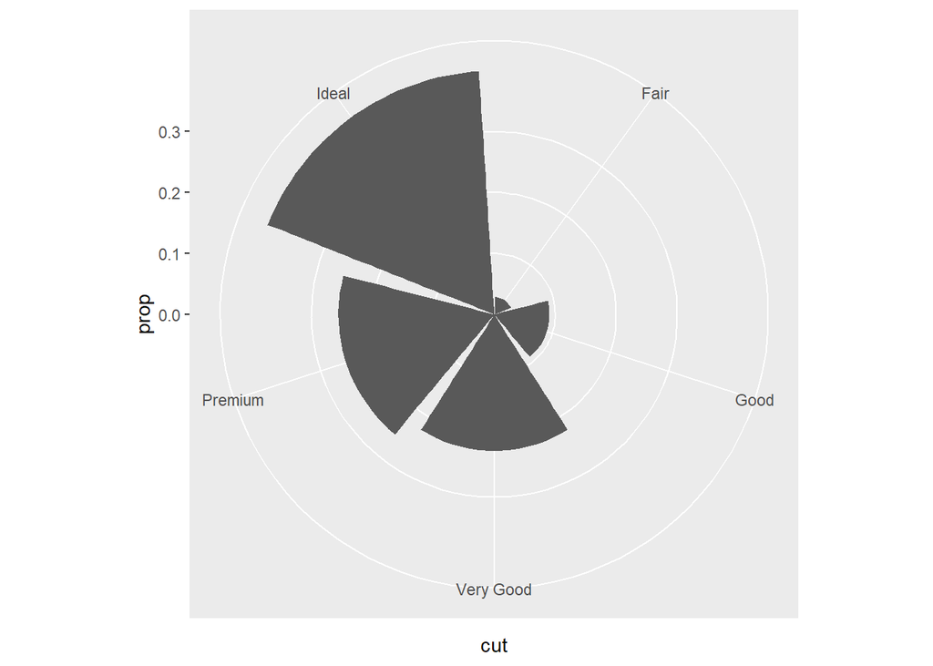

```r
ggplot(data = diamonds) +
  geom_bar(mapping = aes(x = cut, y = ..prop.., group = 1)) +
  coord_polar()
```

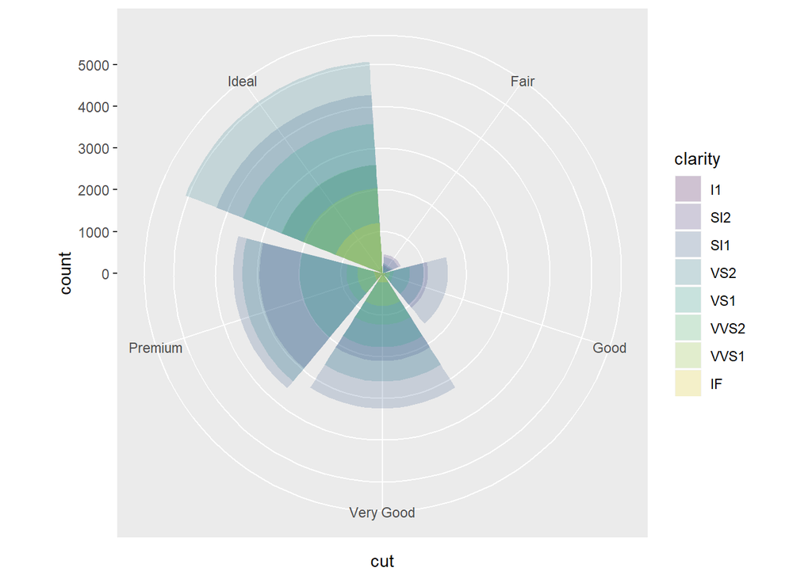

```r
ggplot(data = diamonds, mapping = aes(x = cut, fill = clarity)) +
  geom_bar(alpha = 1/5, position = "identity") +
  coord_polar()
```

2. What does labs() do? Read the documentation.

```r
?labs
```

modifies title, subtiitle, caption, tags and label of the plots.

3. What’s the difference between coord_quickmap() and coord_map()?

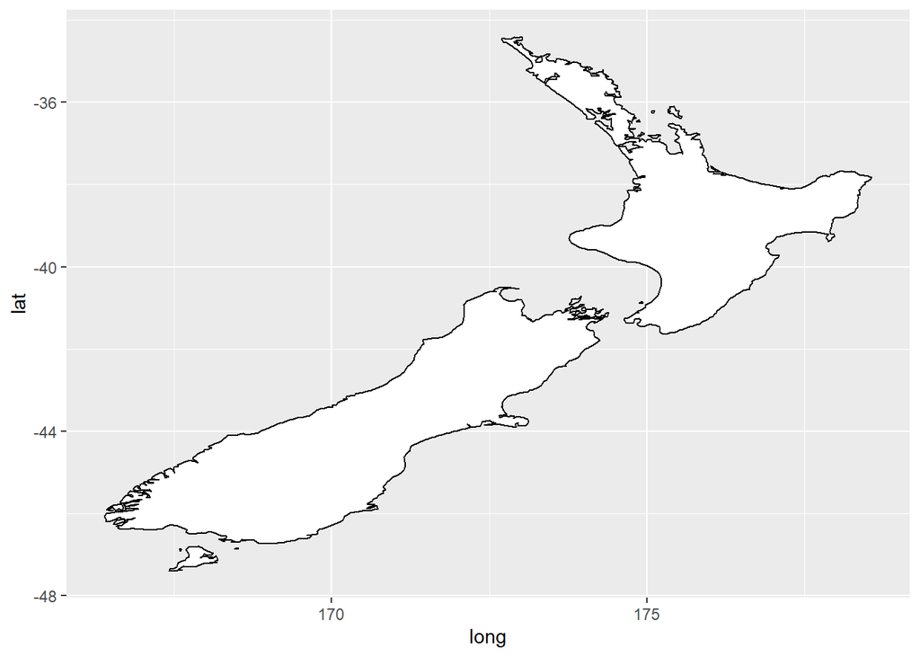

```r
?coord_quickmap
?coord_map

nz <- map_data("nz")

ggplot(nz, aes(long, lat, group = group)) +
  geom_polygon(fill = "white", colour = "black")
```

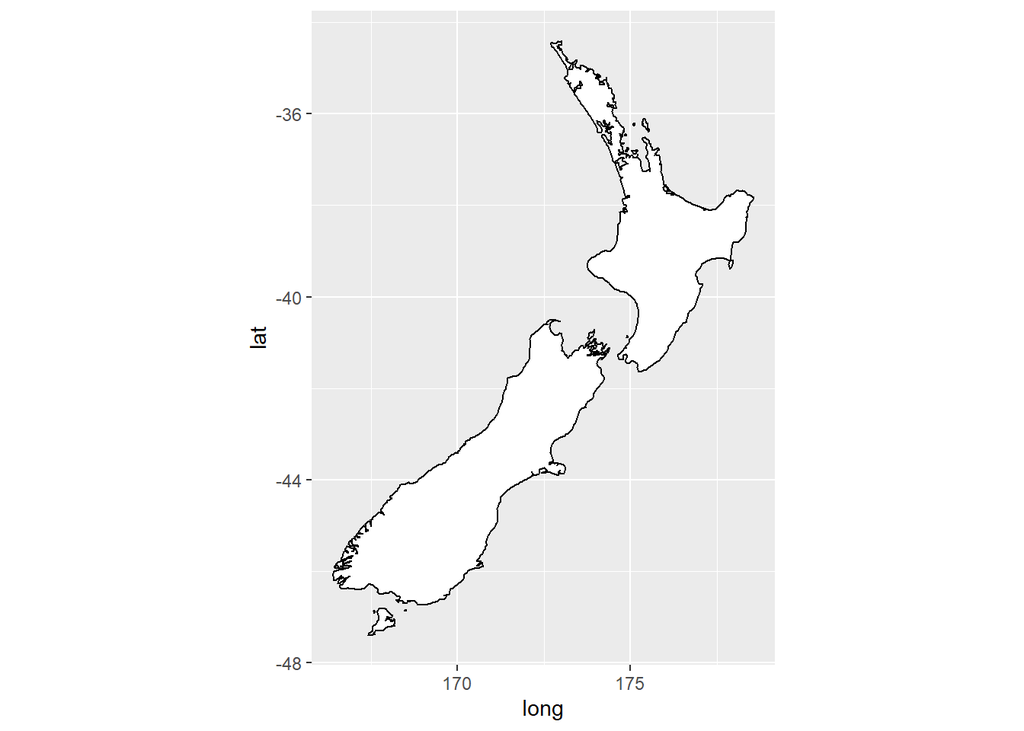

```r
ggplot(nz, aes(long, lat, group = group)) +
  geom_polygon(fill = "white", colour = "black") +
  coord_quickmap()
```

coord_map Maps projections and these projections in genereal doesnot preserve straight lines. coord_quickmap is a quick approximation that preserves the straight lines and takes into account the curvature of the earth by using latitudes and longitudes.

4. What does the plot below tell you about the relationship between city and highway mpg? Why is coord_fixed() important? What does geom_abline() do?

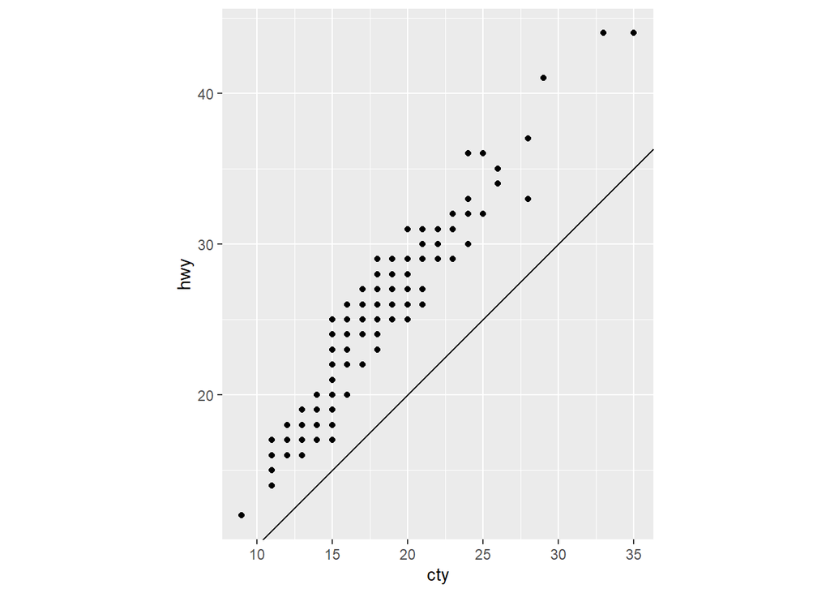

```r
ggplot(data = mpg, mapping = aes(x = cty, y = hwy)) +
  geom_point() +
  geom_abline() +
  coord_fixed()
```

```r
?coord_fixed
?geom_abline
```

geom_abline adds a reference line. coord_fixed makes the ratio of units on the both the axes equal to 1. It is basically used to manipulate the aspect ratio of the plots.